# project_template

## Analyzing the Impact of Race and Gender in Ranked Choice Voting

## Introduction

My companies goal is to increase the popularity for ranked choice voting (RCV) in the U.S. Although it has many benefits, including determining which candidate has the strongest support and reducing wasted votes, not everyone supports it. As my company sees the benefits we are putting our efforts in the form of education and advertisment campaigns to help spread the benefits of RCV. However, we want to ensure that our resources and efforts are not wasted on people that will not budge or already support it.

Therefore, we will analyze survey data in order to determine who already supports it and who might not support it. That way we can determine our best course of action and target audience. With so many variables that impact support or lack therefore, like gender, race, socioeconomic status etc. we have decided to look at two variables: gender and race. We will be using prediction analysis to determine how a person's race and gender will impact their opinions on RCV because we can tailor messages to specific racial groups, addressing their unique concerns or misunderstandings about RCV. As a company we felt this could address how different racial groups and genders have unique historical experiences with the voting system, affecting their trust. Additionally, we chose these as our key variables as past studies show racial and gender disparities. Our goal is to be a part of the solution, not the problem which is we we will use our resources wisely and insightfully.

## Data Description

Our survey will be looking at the Pulse of a nation dataset. 800 people participated in this survey. This dataset includes variables like education, trump support, political leaning and whether they supported (yes, no or DK/REF) RCV. We will focus on gender and race. Gender in this dataset is categorized as female, male, other or DK/REF. The race variable consists of Asian, Latino, Black, White, Other and DK/REF. Below are the summary statistics of race and gender, not yet in relation to ranked choice voting.

```python
import numpy as np
from datascience import *

# These lines do some fancy plotting magic.
import matplotlib
%matplotlib inline
import matplotlib.pyplot as plt

from sklearn.tree import DecisionTreeClassifier, plot_tree
from sklearn.neighbors import KNeighborsClassifier

from sklearn.metrics import confusion_matrix
from sklearn.metrics import accuracy_score, precision_score, recall_score
```

```python
# Load dataset
data = Table.read_table('CAH_PulseoftheNation_FinalProject.csv')
data.show(5)
```

| Gender | Age | Race | Education | Political Affiliation | Political Leaning | Trump | Finances | Fair Elections | Ranked Choice | Woman President | Universal Healthcare |
| --- | --- | --- | --- | --- | --- | --- | --- | --- | --- | --- | --- |
| Female | 81 | White | Some college | Democrat | Liberal | Strongly Disapprove | Not Very Often | No | No | Yes | Yes |
| Male | 80 | Asian | Some college | Democrat | Moderate | Somewhat Disapprove | Somewhat Often | Yes, somewhat confident | Yes | Yes | No |
| Female | 65 | Black | High school or less | Democrat | Moderate | Strongly Disapprove | Somewhat Often | Yes, somewhat confident | Yes | Yes | No |
| Male | 24 | Asian | College degree | Independent | Moderate | Strongly Disapprove | Not Very Often | Yes, somewhat confident | Yes | Yes | No |
| Male | 74 | White | Graduate degree | Democrat | Liberal | Strongly Disapprove | Not Very Often | Yes, very confident | Yes | Yes | Yes |

... (795 rows omitted)

Below are the first rows of the dataset. The irrelevant columns have not been removed yet. Here we can see all the categories from the survey.

```python
# Select columns
relevant_variables = ["Race", "Gender", "Ranked Choice"]
data = data.select(relevant_variables)
data.show(5)
```

| Race | Gender | Ranked Choice |
| --- | --- | --- |
| White | Female | No |
| Asian | Male | Yes |
| Black | Female | Yes |
| Asian | Male | Yes |
| White | Male | Yes |

... (795 rows omitted)

Here we have selected only the variables we want. This would be race, gender, and their opinion on ranked choice. And once again only the first few rows are shown.

```python
# race in numbers
data.group("Race").show()
```

| Race | count |
| --- | --- |
| Asian | 23 |
| Black | 91 |
| DK/REF | 30 |
| Latino | 36 |
| Other | 15 |
| White | 605 |

Here we can see the the number of respondents by race. For example, we can see that white's responded the most, with over 600. We want to keep this in mind when analyzing our results later.

```python
# gender in numbers
data.group("Gender").show()
```

| Gender | count |
| --- | --- |
| DK/REF | 4 |
| Female | 428 |
| Male | 354 |
| Other | 14 |

Here we can see number of respondents by gender. The results show that females responded more than men but not by a drastic amount. We should also note that there were 14 people that didn't identify as female or male.

```python
# RCV in numbers
data.group("Ranked Choice").show()
```

| Ranked Choice | count |
| --- | --- |
| DK/REF | 69 |
| No | 345 |
| Yes | 386 |

This just shows us the overall proportion of people that support versus don't support RCV. It seems that they are very similar in proportion. Out of all the graphs so far this also had the highest number of people that didn't know or refused to answer.

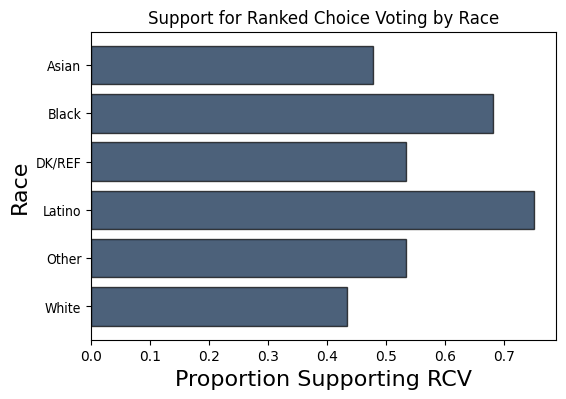

```python
# by race with RCV
# use bar graph for categorical
race_support = data.group("Race").join(
    "Race",
    data.select("Race", "Ranked Choice").group("Race", lambda rows: np.mean(rows == "Yes"))
).relabel("Ranked Choice", "Ranked Choice Support")
race_support.barh("Race", "Ranked Choice Support")
plt.title("Support for Ranked Choice Voting by Race")
plt.xlabel("Proportion Supporting RCV")
plt.ylabel("Race")
plt.show()
```

This shows the proportion of support for ranked choice voting by race. We can see that black and latino races are at the highest for support. White's on the other hand are the lowest, not even reaching 50 percent support.

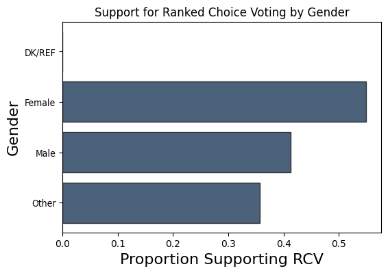

```python
# by gender with RCV

gender_support = data.group("Gender").join(
    "Gender",
    data.select("Gender", "Ranked Choice").group("Gender", lambda rows: np.mean(rows == "Yes"))
).relabel("Ranked Choice", "Ranked Choice Support")
# bar graph
gender_support.barh("Gender", "Ranked Choice Support")

# labels
plt.title("Support for Ranked Choice Voting by Gender")
plt.xlabel("Proportion Supporting RCV")
plt.ylabel("Gender")
plt.show()
```

This shows the proportion of support for ranked choice voting by gender. We can see that all categories except female don't reach 50 percent. Even female barely exceeds 50 which could indicate a focus on male and other but there being no harm in also targeting females.

## Inference: Hypothesis Test or Confidence Interval

Next our company wants to determine if there is a significant difference in the proportion of people who support ranked choice voting based on another categorical variable (such as gender or race). That is why we will use a hypothesis test. Specifically, we want to determine if there is a significant difference in the proportions of support for ranked choice voting between males vs. females for gender and whites vs. blacks for race. Therefore, we will calculate the observed statistic (difference in proportions) and use bootstrap resampling to ultimately calculate the p-value. The p-value will help us determine whether the observed difference is significant or if it is likely due to chance, giving us a more accurate understanding about where we should implement our resources and education.

```python
# Define the function to calculate the observed statistic (difference in proportions)
def statistic(data):


    # Females
    group1_data = data.where('Gender', 'Female')
    prop_female = group1_data.where('Ranked Choice', 'Yes').num_rows / group1_data.num_rows
    # males
    group2_data = data.where('Gender', 'Male')
    prop_male = group2_data.where('Ranked Choice', 'Yes').num_rows / group2_data.num_rows
    # Calculate the observed difference in proportions
    observed = prop_female - prop_male

    return observed

# Call the function and store the result
observed_statistic = statistic(data)
observed_statistic
```

```
0.13663604202967428
```

```python
shuffled_gender = data.select('Gender').sample(with_replacement=False).column('Gender')

simulated_data = data.with_column(
    'Gender', shuffled_gender
)

simulated_data.show(5)

simulated_statistic = statistic(simulated_data)
simulated_statistic
```

| Race | Gender | Ranked Choice |
| --- | --- | --- |
| White | Female | No |
| Asian | Female | Yes |
| Black | Male | Yes |
| Asian | Male | Yes |
| White | Other | Yes |

... (795 rows omitted)

```
0.011893447383705624
```

```python
# now do 1000 repetitions
def simulation_and_statistic():
    '''
    Simulates shuffling the Gender column and calculating the difference in proportions
    of support for ranked choice voting between males and females.

    Returns the observed difference in proportions.
    '''

    shuffled_gender = data.select('Gender').sample(with_replacement=False).column('Gender')


    simulated_data = data.with_column('Gender', shuffled_gender)



    # Calculate the proportions for each group (males and females)
    prop_male_simulated = simulated_data.where('Gender', 'Male').where('Ranked Choice', 'Yes').num_rows / simulated_data.where('Gender', 'Male').num_rows
    prop_female_simulated = simulated_data.where('Gender', 'Female').where('Ranked Choice', 'Yes').num_rows / simulated_data.where('Gender', 'Female').num_rows

    # Calculate the difference in proportions (observed statistic)
    observed_diff_sim = prop_female_simulated - prop_male_simulated

    return observed_diff_sim

print(f"Observed Statistic: {observed_statistic}")
```

```
Observed Statistic: 0.13663604202967428
```

```python
# now put in loop
num_repetitions = 1000

# in array
simulated_statistics = np.array([])

for _ in range(num_repetitions):
    simulated_stat = simulation_and_statistic()
    simulated_statistics = np.append(simulated_statistics, simulated_stat)

# Print the simulated statistics
print(simulated_statistics)
```

[output not shown]

[output cut: 195 more lines]

[output not shown]

```python
p_value = np.mean(simulated_statistics >= observed_statistic)
p_value
```

```
0.0
```

The difference in support between genders was found to be statistically significant with a p-value of 0. This indicates that gender (female vs. male) does play a significant role in determining whether individuals support ranked choice voting. Based on our original proportions in the data description section we saw that women supproted it more, and now that we know that this is likely statistically significant we have answered who already supports RCV and put our resources more towards males.

Now let us take a look at race!

```python
# black and white
# Define the function to calculate the observed statistic (difference in proportions)
def statistic_two(data):


    # Black
    group1_data = data.where('Race', 'Black')
    prop_black = group1_data.where('Ranked Choice', 'Yes').num_rows / group1_data.num_rows
    # White
    group2_data = data.where('Race', 'White')
    prop_white = group2_data.where('Ranked Choice', 'Yes').num_rows / group2_data.num_rows
    # Calculate the observed difference in proportions
    observed = prop_black - prop_white

    return observed

# Call the function and store the result
observed_statistic_two = statistic_two(data)
observed_statistic_two
```

```
0.2482608300790119
```

```python
shuffled_race = data.select('Race').sample(with_replacement=False).column('Race')

simulated_data_two = data.with_column(
    'Race', shuffled_race
)

simulated_data_two.show(5)

simulated_statistic_two = statistic_two(simulated_data_two)
simulated_statistic_two
```

| Race | Gender | Ranked Choice |
| --- | --- | --- |
| White | Female | No |
| Black | Male | Yes |
| White | Female | Yes |
| White | Male | Yes |
| White | Male | Yes |

... (795 rows omitted)

```
-0.021106166560712014
```

```python
# now do 1000 repetitions
def simulation_and_statistic_two():
    '''
    Simulates shuffling the Race column and calculating the difference in proportions
    of support for ranked choice voting between whites and blacks.

    Returns the observed difference in proportions.
    '''

    shuffled_race = data.select('Race').sample(with_replacement=False).column('Race')


    simulated_data_two = data.with_column('Race', shuffled_race)

    # Calculate the proportions for each group (males and females)
    prop_black_simulated = simulated_data_two.where('Race', 'Black').where('Ranked Choice', 'Yes').num_rows / simulated_data_two.where('Race', 'Black').num_rows
    prop_white_simulated = simulated_data_two.where('Race', 'White').where('Ranked Choice', 'Yes').num_rows / simulated_data_two.where('Race', 'White').num_rows

    # Calculate the difference in proportions (observed statistic)
    observed_diff_sim_two = prop_black_simulated - prop_white_simulated

    return observed_diff_sim_two


num_repetitions = 1000

# in array
simulated_statistics_two = np.array([])

for _ in range(num_repetitions):
    simulated_stat_two = simulation_and_statistic_two()
    simulated_statistics_two = np.append(simulated_statistics_two, simulated_stat_two)

# Print the simulated statistics
print(simulated_statistics_two)
```

[output not shown]

[output cut: 112 more lines]

[output not shown]

```python
p_value = np.mean(simulated_statistics_two >= observed_statistic_two)
p_value
```

```
0.0
```

We also analyzed support for ranked choice voting across racial groups. The hypothesis test showed statistical significance, suggesting that race may influence support for ranked choice voting. This tells us that blacks support RCV more and therefore our education and resources should go towards convincing the white population.

## Prediction

The model-building process starts by looking at a threshold of .5 with tree one at a depth of 1, tree 2 at a depth of 2 and tree three at a depth of 3. Based on the confusion matrix results of that we move on to trying more thresholds to ensure we find the best model. We use the accuracy_score, precision_score, and recall_score along with our original results to measure which combination ensures the best model. Our company went through this entire process and determined that the best model was the threshold of .1 and a depth of 1. This model has a precision score of 0.45625 and a recall score of 1.

note: more info below

```python
# clean to focus only on yes and no
data_cleaned = data.where('Ranked Choice', are.not_equal_to('DK/REF'))
```

```python
data_cleaned.group('Ranked Choice')
```

| Ranked Choice | count |
| --- | --- |
| No | 345 |
| Yes | 386 |

```python
def create_label(response):
    '''
    For a Ranked Choice Voting response, turns it into a 1 or 0 depending on the answer.

    Arguments:
    response: str, the response to the Ranked Choice Voting question.

    Returns:
    A binary value (1 for support, 0 for no support).
    '''

    if response == 'Yes':
        return 1  # Support for Ranked Choice Voting
    else:
        return 0  # No support for Ranked Choice Voting
```

```python
data_cleaned = data.apply(create_label, 'Ranked Choice')
data_cleaned
```

[output not shown]

[output cut: 20 more lines]

```python
# Remove rows with invalid or missing values in the 'Race' and 'Gender' columns
# For race this is only DK/REF
data_cleaned = data.where('Race', are.not_equal_to('DK/REF'))  # Remove 'DK/REF' for race

# for gender the same
data_cleaned = data.where('Gender', are.not_equal_to('DK/REF'))
data_cleaned
```

| Race | Gender | Ranked Choice |
| --- | --- | --- |
| White | Female | No |
| Asian | Male | Yes |
| Black | Female | Yes |
| Asian | Male | Yes |
| White | Male | Yes |
| Black | Female | Yes |
| Asian | Female | No |
| Black | Female | Yes |
| White | Female | No |
| White | Female | No |

... (786 rows omitted)

```python
# Assuming data_cleaned is your dataset

# Convert categorical columns into numeric (0/1) values
data_cleaned = data_cleaned.with_columns(
    "Black", np.where(data_cleaned.column("Race") == "Black", 1, 0),
    "White", np.where(data_cleaned.column("Race") == "White", 1, 0),
    "Asian", np.where(data_cleaned.column("Race") == "Asian", 1, 0),
    "Latino", np.where(data_cleaned.column("Race") == "Latino", 1, 0),
    "Other_Race", np.where(data_cleaned.column("Race") == "Other", 1, 0),

    "Male", np.where(data_cleaned.column("Gender") == "Male", 1, 0),
    "Female", np.where(data_cleaned.column("Gender") == "Female", 1, 0),
    "Other_Gender", np.where(data_cleaned.column("Gender") == "Other", 1, 0),

    "Ranked_Choice", np.where(data_cleaned.column("Ranked Choice") == "Yes", 1, 0)  # Convert Ranked Choice to binary
)

# Now check the first 5 rows
data_cleaned.show(5)
```

| Race | Gender | Ranked Choice | Black | White | Asian | Latino | Other_Race | Male | Female | Other_Gender | Ranked_Choice |
| --- | --- | --- | --- | --- | --- | --- | --- | --- | --- | --- | --- |
| White | Female | No | 0 | 1 | 0 | 0 | 0 | 0 | 1 | 0 | 0 |
| Asian | Male | Yes | 0 | 0 | 1 | 0 | 0 | 1 | 0 | 0 | 1 |
| Black | Female | Yes | 1 | 0 | 0 | 0 | 0 | 0 | 1 | 0 | 1 |
| Asian | Male | Yes | 0 | 0 | 1 | 0 | 0 | 1 | 0 | 0 | 1 |
| White | Male | Yes | 0 | 1 | 0 | 0 | 0 | 1 | 0 | 0 | 1 |

... (791 rows omitted)

#### Step 1: Create train and test set

```python
# Find the number of rows you want to take by multiplying the number of rows in data by 0.8
rows_to_take = int(data_cleaned.num_rows * 0.8)

# Shuffle the data to ensure randomness
shuffled_data = data_cleaned.sample(with_replacement=False)

# Split the data into train and test
train = shuffled_data.take(np.arange(rows_to_take))
test = shuffled_data.take(np.arange(rows_to_take, data_cleaned.num_rows))
```

```python
train.num_rows
```

```
636
```

```python
test.num_rows
```

```
160
```

```python
threshold = 0.5

predictors = ['Black', 'White', 'Asian', 'Latino', 'Other_Race', 'Male', 'Female', 'Other_Gender']
outcome = 'Ranked_Choice'

# Make predictions on test data for each model
tree_predicted = tree.predict_proba(test.select(predictors).rows)[:, 1] > threshold
tree2_predicted = tree2.predict_proba(test.select(predictors).rows)[:, 1] > threshold
tree3_predicted = tree3.predict_proba(test.select(predictors).rows)[:, 1] > threshold


# Get the expected labels (true values) from the test set
expected = test.column(outcome)

conf_matrix_tree = confusion_matrix(expected, tree_predicted)
conf_matrix_tree2 = confusion_matrix(expected, tree2_predicted)
conf_matrix_tree3 = confusion_matrix(expected, tree3_predicted)


# Display the confusion matrix for each
print("Confusion Matrix for Tree Depth 1:")
print(conf_matrix_tree)

print("Confusion Matrix for Tree Depth 2:")
print(conf_matrix_tree2)

print("Confusion Matrix for Tree Depth 3:")
print(conf_matrix_tree3)
```

```
Confusion Matrix for Tree Depth 1:
[[36 51]
 [17 56]]
Confusion Matrix for Tree Depth 2:
[[35 52]
 [16 57]]
Confusion Matrix for Tree Depth 3:
[[36 51]
 [17 56]]
```

Now we should look at the accuracy, precision and recal score to determine the best model

```python
# for the first tree model
# Accuracy
accuracy_tree = accuracy_score(expected, tree_predicted)
print(f'Accuracy: {accuracy_tree}')

# Precision and Recall
precision_tree = precision_score(expected, tree_predicted)
recall_tree = recall_score(expected, tree_predicted)
print(f'Precision: {precision_tree}, Recall: {recall_tree}')
```

```
Accuracy: 0.575
Precision: 0.5233644859813084, Recall: 0.7671232876712328
```

```python
# for tree2
accuracy_tree2 = accuracy_score(expected, tree2_predicted)
precision_tree2 = precision_score(expected, tree2_predicted)
recall_tree2 = recall_score(expected, tree2_predicted)
print(f'Accuracy: {accuracy_tree2}')
print(f'Precision: {precision_tree2}, Recall: {recall_tree2}')
```

```
Accuracy: 0.575
Precision: 0.5229357798165137, Recall: 0.7808219178082192
```

```python
# for tree3

accuracy_tree3 = accuracy_score(expected, tree3_predicted)
precision_tree3 = precision_score(expected, tree3_predicted)
recall_tree3 = recall_score(expected, tree3_predicted)

print(f'Accuracy: {accuracy_tree3}')
print(f'Precision: {precision_tree3}, Recall: {recall_tree3}')
```

```
Accuracy: 0.575
Precision: 0.5233644859813084, Recall: 0.7671232876712328
```

```python
#results in array
thresholds = np.array([])
depths = np.array([])
precisions = np.array([])
recalls = np.array([])

# Define the predictors and outcome
predictors = ['Black', 'White', 'Asian', 'Latino', 'Other_Race', 'Male', 'Female', 'Other_Gender']
outcome = 'Ranked_Choice'

# Convert to array
X_train = np.array(train.select(predictors).rows)
y_train = np.array(train.column(outcome))

# Convert to array
X_test = np.array(test.select(predictors).rows)
expected = np.array(test.column(outcome))

# different threshold values and depths
for threshold in [0.1, 0.2, 0.3, 0.4, 0.5]:  # Adjusted to directly use Python lists
    for depth in [1,2,3]:
        # Train the decision tree model with the current depth
        tree = DecisionTreeClassifier(max_depth=depth)
        tree.fit(X=X_train, y=y_train)


        probs = tree.predict_proba(X_test)[:, 1]


        predicted = (probs >= threshold).astype(int)

        # Calculate precision and recall
        precision = precision_score(expected, predicted)
        recall = recall_score(expected, predicted)

        # results
        thresholds = np.append(thresholds, threshold)
        depths = np.append(depths, depth)
        precisions = np.append(precisions, precision)
        recalls = np.append(recalls, recall)
```

```python
# Create a table for results
tree_results = Table().with_columns(
    'Threshold', thresholds,
    'Max Depth', depths,
    'Precision', precisions,
    'Recall', recalls
)

# Show the first 20 rows of the results
tree_results.show(20)
```

| Threshold | Max Depth | Precision | Recall |
| --- | --- | --- | --- |
| 0.1 | 1 | 0.45625 | 1 |
| 0.1 | 2 | 0.45625 | 1 |
| 0.1 | 3 | 0.45625 | 1 |
| 0.2 | 1 | 0.45625 | 1 |
| 0.2 | 2 | 0.45625 | 1 |
| 0.2 | 3 | 0.45625 | 1 |
| 0.3 | 1 | 0.45625 | 1 |
| 0.3 | 2 | 0.45625 | 1 |
| 0.3 | 3 | 0.45625 | 1 |
| 0.4 | 1 | 0.45625 | 1 |
| 0.4 | 2 | 0.522124 | 0.808219 |
| 0.4 | 3 | 0.522124 | 0.808219 |
| 0.5 | 1 | 0.644444 | 0.39726 |
| 0.5 | 2 | 0.522936 | 0.780822 |
| 0.5 | 3 | 0.513761 | 0.767123 |

```python
tree_results.sort('Precision', descending = True)
```

| Threshold | Max Depth | Precision | Recall |
| --- | --- | --- | --- |
| 0.5 | 1 | 0.644444 | 0.39726 |
| 0.5 | 2 | 0.522936 | 0.780822 |
| 0.4 | 2 | 0.522124 | 0.808219 |
| 0.4 | 3 | 0.522124 | 0.808219 |
| 0.5 | 3 | 0.513761 | 0.767123 |
| 0.1 | 1 | 0.45625 | 1 |
| 0.1 | 2 | 0.45625 | 1 |
| 0.1 | 3 | 0.45625 | 1 |
| 0.2 | 1 | 0.45625 | 1 |
| 0.2 | 2 | 0.45625 | 1 |

... (5 rows omitted)

```python
tree_results.sort('Recall', descending = True)
```

| Threshold | Max Depth | Precision | Recall |
| --- | --- | --- | --- |
| 0.1 | 1 | 0.45625 | 1 |
| 0.1 | 2 | 0.45625 | 1 |
| 0.1 | 3 | 0.45625 | 1 |
| 0.2 | 1 | 0.45625 | 1 |
| 0.2 | 2 | 0.45625 | 1 |
| 0.2 | 3 | 0.45625 | 1 |
| 0.3 | 1 | 0.45625 | 1 |
| 0.3 | 2 | 0.45625 | 1 |
| 0.3 | 3 | 0.45625 | 1 |
| 0.4 | 1 | 0.45625 | 1 |

... (5 rows omitted)

[figure not shown]

```python
plt.figure(figsize=(10, 6))
plot_tree(tree,
          feature_names=predictors)

plt.title("Decision Tree - Depth 1")
plt.show()
```

The final prediction and model identifies individuals who, based on race and gender, are more likely to fall into the "support" category for RCV. The model helps us target specific groups—like Whites who are less likely to support RCV.

## Conclusion

The findings from our machine learning analysis, which identified race as the predominant factor in predicting support for ranked choice voting (RCV), are essential for the effective allocation of our resources. The decision tree model indicated that "Whites" occupy the top position, underscoring the significant influence of race on RCV support. In conjunction with our hypothesis testing results, which revealed statistically significant variations in support based on gender and race, these insights enable us to enhance our outreach strategy. Notably, the hypothesis test indicated that Black individuals exhibit a higher likelihood of supporting RCV, while women demonstrate stronger support compared to their male counterparts. By concentrating our efforts on educating and persuading the male and White demographics, we can optimize the effectiveness of our campaigns, ensuring that our resources are directed towards those less inclined to support RCV. This strategy is in line with our overarching objective of increasing the popularity of RCV in the United States by targeting appropriate demographics.